# From page to screen

## Comparing books to movie adaptations

[figure not shown]

Lily Zhang  
CMSC 320 Summer 2019

## Introduction

Books and movies are two beloved forms of entertainment that often borrow from one another. In this notebook, I will be examining books that have been made into film adaptations to learn how the quality of a story changes when transfered from page to screen, as measured by user ratings.

## Contents

1. Introduction
2. Data sources
3. MovieLens dataset
4. Goodreads dataset
5. Connecting books to movie adaptations
6. Adaptations by genre
7. Film vs Book rankings
8. Film vs Book rankings: By genre
9. Film vs Book rankings: By genre with Hypothesis Testing
10. Film vs Book rankings: Especially high-ranking books
11. Film vs Book rankings: Ratings over time
12. Machine Learning: Predicting if a book will be adapted for the screen

## Data sources used

For this project, I used two datasets. **Goodreads** is a site that allows users to log books they have read and rate and write reviews for them, among other things. The Goodreads dataset I used is not directly from the Goodreads API, but rather a simplified, more comprehensive, cleaner dataset that was formed from the API and posted on Kaggle. 12,475 books of those that existed on Goodreads as of June 2019 are in this dataset, along with their average user-given ratings.

[Click here to view the Goodreads dataset on Kaggle.](https://www.kaggle.com/jealousleopard/goodreadsbooks)

**MovieLens** is a site that provides personalized film recommendations based on how you have rated other films. The version I am using is a stable dataset from 2017 that includes all 45,000 films that were on MovieLens at the time of scraping. There are more recent datasets with more films, but I am using the stable dataset so that anyone can reproduce the results below if they are tempted.

[Click here to view the MovieLens dataset on Kaggle.](https://www.kaggle.com/rounakbanik/the-movies-dataset)

## Taking a look at the data: MovieLens

To begin, we can import the datasets in their csv format and convert them into Pandas DataFrames that will allow us to see what the data looks like.

```python
import pandas as pd

# Read movies dataset
movies = pd.read_csv('movies/movies_metadata.csv')
# Drop unnecessary columns
movies.drop(inplace=True, columns=['adult', 'homepage', 'poster_path', 'belongs_to_collection', 'budget', 'overview', 'status', 'video', 'imdb_id', 'tagline'])
# Drop rows with no titles
movies.dropna(subset=['title'], inplace=True)

# Create a'summary' data frame with fewer attributes for quick reference
movies_summary = movies.loc[:,['id','original_title','title','release_date','vote_average','vote_count']]
movies_summary.head(10)

movies_summary.sort_values(by='release_date').head(10)
```

|  | id | original_title | title | release_date | vote_average | vote_count |
| --- | --- | --- | --- | --- | --- | --- |
| 34940 | 315946 | Passage de Venus | Passage of Venus | 1874-12-09 | 6.0 | 19.0 |
| 34937 | 194079 | Sallie Gardner at a Gallop | Sallie Gardner at a Gallop | 1878-06-14 | 6.2 | 25.0 |
| 41602 | 426903 | Buffalo Running | Buffalo Running | 1883-11-19 | 5.4 | 7.0 |
| 34933 | 159897 | Man Walking Around a Corner | Man Walking Around a Corner | 1887-08-18 | 4.1 | 17.0 |
| 34934 | 96882 | Accordion Player | Accordion Player | 1888-01-01 | 4.4 | 18.0 |
| 34938 | 16464 | Traffic Crossing Leeds Bridge | Traffic Crossing Leeds Bridge | 1888-10-15 | 5.9 | 25.0 |
| 34939 | 33316 | London's Trafalgar Square | London's Trafalgar Square | 1890-01-01 | 5.1 | 9.0 |
| 41194 | 386743 | Mosquinha | Mosquinha | 1890-03-09 | 6.5 | 2.0 |
| 34935 | 32571 | Monkeyshines, No. 1 | Monkeyshines, No. 1 | 1890-11-21 | 4.3 | 15.0 |
| 34936 | 33315 | Monkeyshines, No. 2 | Monkeyshines, No. 2 | 1890-11-21 | 4.5 | 12.0 |

Here, we can view all films sorted by release date in ascending order. As you can see, the oldest film logged in MovieLens came out in 1874.

Alternately, we can sort by vote count to see which films have received the greatest number of vote counts from MovieLens users.

```python
movies_summary.sort_values(by='vote_count', ascending=False).head(10)
```

|  | id | original_title | title | release_date | vote_average | vote_count |
| --- | --- | --- | --- | --- | --- | --- |
| 15480 | 27205 | Inception | Inception | 2010-07-14 | 8.1 | 14075.0 |
| 12481 | 155 | The Dark Knight | The Dark Knight | 2008-07-16 | 8.3 | 12269.0 |
| 14551 | 19995 | Avatar | Avatar | 2009-12-10 | 7.2 | 12114.0 |
| 17818 | 24428 | The Avengers | The Avengers | 2012-04-25 | 7.4 | 12000.0 |
| 26564 | 293660 | Deadpool | Deadpool | 2016-02-09 | 7.4 | 11444.0 |
| 22879 | 157336 | Interstellar | Interstellar | 2014-11-05 | 8.1 | 11187.0 |
| 20051 | 68718 | Django Unchained | Django Unchained | 2012-12-25 | 7.8 | 10297.0 |
| 23753 | 118340 | Guardians of the Galaxy | Guardians of the Galaxy | 2014-07-30 | 7.9 | 10014.0 |
| 2843 | 550 | Fight Club | Fight Club | 1999-10-15 | 8.3 | 9678.0 |
| 18244 | 70160 | The Hunger Games | The Hunger Games | 2012-03-12 | 6.9 | 9634.0 |

Here are some summary statistics of the MovieLens dataFrame. There are a total of 45,460 movies in the dataset. The average score of a movie is 5.6/10.0, and the number of votes that movies receive range from 0 to 14,075 votes, with a median of 10 votes.

```python
movies.describe()
```

|  | revenue | runtime | vote_average | vote_count |
| --- | --- | --- | --- | --- |
| count | 4.546000e+04 | 45203.000000 | 45460.000000 | 45460.000000 |
| mean | 1.120935e+07 | 94.128199 | 5.618207 | 109.897338 |
| std | 6.433225e+07 | 38.407810 | 1.924216 | 491.310374 |
| min | 0.000000e+00 | 0.000000 | 0.000000 | 0.000000 |
| 25% | 0.000000e+00 | 85.000000 | 5.000000 | 3.000000 |
| 50% | 0.000000e+00 | 95.000000 | 6.000000 | 10.000000 |
| 75% | 0.000000e+00 | 107.000000 | 6.800000 | 34.000000 |
| max | 2.787965e+09 | 1256.000000 | 10.000000 | 14075.000000 |

## Goodreads

Next, we can import the Goodreads dataset. I will apply some transformations that I will explain in depth below.

```python
# Read goodreads dataset
books = pd.read_csv('goodreads.csv', error_bad_lines=False, converters={'title':str})

# For books in a series, separate the book name from the series name
import re
series_regex = re.compile("^(.+)\s*\(.+#\d{1,}.*\)$")

def get_title(full_title):
    match = series_regex.match(full_title)
    if match:
        return match.group(1)
    else:
        return full_title

books['actual_title'] = books['title'].apply(get_title)
books.rename(columns={ 'title' : 'title_w_series', 'actual_title' : 'title'}, inplace=True)

# Extract the primary (first) author
# This only works for Western names with a first and last name.
# This doesn't work correctly if the primary author has a hyphen in their name.
# It will truncate the author's name before the hyphen.
dash_regex = re.compile("-")
author_regex = re.compile("^(.*?)-")
def get_primary_author(authors):
    dash_match = dash_regex.search(authors)
    if dash_match:
        match = author_regex.match(authors)
        return match.group(1)
    else:
        return authors

# Create new column to indicate primary author
books['primary_author'] = books['authors'].apply(get_primary_author)
# Change order of columns
books = books[['bookID', 'title', 'primary_author', 'title_w_series', 'authors', 'average_rating', 'isbn',
       'isbn13', 'language_code', '# num_pages', 'ratings_count',
       'text_reviews_count']]

# Sort by ratings so that when we remove duplicates, the highest rating remains
books.sort_values(by='average_rating', ascending=False, inplace=True)

# Only keep one row for each (author, title) combination, even if they have different ISBNs.
books.drop_duplicates(subset=['title','primary_author'], inplace=True)

books.sort_values(by='bookID', inplace=True)
books.head(5)
```

```
b'Skipping line 4012: expected 10 fields, saw 11\nSkipping line 5688: expected 10 fields, saw 11\nSkipping line 7056: expected 10 fields, saw 11\nSkipping line 10601: expected 10 fields, saw 11\nSkipping line 10668: expected 10 fields, saw 11\n'
```

|  | bookID | title | primary_author | title_w_series | authors | average_rating | isbn | isbn13 | language_code | # num_pages | ratings_count | text_reviews_count |
| --- | --- | --- | --- | --- | --- | --- | --- | --- | --- | --- | --- | --- |
| 1 | 2 | Harry Potter and the Order of the Phoenix | J.K. Rowling | Harry Potter and the Order of the Phoenix (Har... | J.K. Rowling-Mary GrandPré | 4.49 | 0439358078 | 9780439358071 | eng | 870 | 1996446 | 27613 |
| 3 | 4 | Harry Potter and the Chamber of Secrets | J.K. Rowling | Harry Potter and the Chamber of Secrets (Harry... | J.K. Rowling | 4.41 | 0439554896 | 9780439554893 | eng | 352 | 6267 | 272 |
| 5 | 8 | Harry Potter Boxed Set Books 1-5 | J.K. Rowling | Harry Potter Boxed Set Books 1-5 (Harry Potte... | J.K. Rowling-Mary GrandPré | 4.78 | 0439682584 | 9780439682589 | eng | 2690 | 38872 | 154 |
| 6 | 9 | Unauthorized Harry Potter Book Seven News: "Ha... | W. Frederick Zimmerman | Unauthorized Harry Potter Book Seven News: "Ha... | W. Frederick Zimmerman | 3.69 | 0976540606 | 9780976540601 | en-US | 152 | 18 | 1 |
| 7 | 10 | Harry Potter Collection | J.K. Rowling | Harry Potter Collection (Harry Potter #1-6) | J.K. Rowling | 4.73 | 0439827604 | 9780439827607 | eng | 3342 | 27410 | 820 |

This is the Goodreads dataset, ordered by index.

The 'authors' attribute in the Kaggle dataset was formatted as a hyphen-delimited string of the authors, translators, illustrators, etc. for a particular book. Unfortunately, this makes it difficult to parse because some people have hyphens in their name. To simplify things, I create a 'primary author' field that takes the first name before any appearance of a hyphen. This rough parsing is sufficient because I only use the author to distinguish books with the same title. In addition, the authors are listed in an arbitrary order, so sometimes an illustrator or translator will take the spot of the 'primary author' even if this is not accurate. Again, it is okay because this column is only used to differentiate books with the same title.

The purpose of extracting the primary author is for the case where a single piece of writing is published or reprinted in different editions over time under different ISBNs. This applies especially to works that have been around for a while (think 19th-century classics and high school English class text). To simplify, I only keep a single entry for each book with the highest rating that any of them received. I distinguish a "book" by a unique (Primary Author, Title) pair.

Here are some summary statistics of our book data. There are 12,475 books, and the mean rating was 3.93/5.00. The mean number of ratings received is 13,357, while the median number of ratings received is 633. There are about 1/4 the number of books on Goodreads as there are movies on MovieLens, but far more ratings per book on average.

```python
books.describe()
```

|  | bookID | average_rating | isbn13 | # num_pages | ratings_count | text_reviews_count |
| --- | --- | --- | --- | --- | --- | --- |
| count | 12475.000000 | 12475.000000 | 1.247500e+04 | 12475.000000 | 1.247500e+04 | 12475.000000 |
| mean | 22594.179078 | 3.928819 | 9.762338e+12 | 339.241924 | 1.335745e+04 | 433.507014 |
| std | 13643.668851 | 0.367285 | 4.180657e+11 | 252.494714 | 7.604515e+04 | 1896.538075 |
| min | 2.000000 | 0.000000 | 8.987060e+09 | 0.000000 | 0.000000e+00 | 0.000000 |
| 25% | 11069.500000 | 3.770000 | 9.780349e+12 | 194.000000 | 7.900000e+01 | 7.000000 |
| 50% | 22196.000000 | 3.960000 | 9.780619e+12 | 296.000000 | 6.330000e+02 | 39.000000 |
| 75% | 33728.000000 | 4.140000 | 9.780965e+12 | 416.000000 | 4.667500e+03 | 209.000000 |
| max | 47709.000000 | 5.000000 | 9.790008e+12 | 6576.000000 | 2.364968e+06 | 54668.000000 |

## Normalizing ratings

Before we connect and books and movies, I'll normalize book and movie ratings so they can be compared directly. At present, books are scored out of 5 points, while movies are out of 10 points. Since both point systems measure a proportion rather than an absolute value, I'll divide book ratings by 5 and movies by 10 so they will both be on a 0 to 1 scale.

```python
books['average_rating'] = books['average_rating'].apply(lambda x : x / 5)
movies['vote_average'] = movies['vote_average'].apply(lambda x : x / 10)
```

## Connecting books to movie adaptations

For some book-movie pairs, the relationship is obvious because they have the same title, or because the relationship is simply well known and well documented in popular culture. For others, the relationship is not so obvious, as book-to-movie adaptations are often given different titles. For example, Steven Spielberg's *Schinder's List* (1994) is based on an Austrian novel by the name of *Schindler's Ark*. Sacrificing the size of our dataset for accuracy, I will be looking only at movie adaptations that have the same title as the original books.

This method of record linkage sometimes generates matches between books and movies that are not actually related. For example, *Heat* is the name of a 1985 novel by William Goldman, as well as of a 2006 novel by Mike Lupica. It is also the name of three separate American movies released in 1972, 1986, and 1995. It happens that the 1986 film is an adaptation of the 1985 novel, but the other two are unrelated to any of the novels and coincidentally share the same name. In order to avoid false matches like this, I will be considering book and movie titles with two or more words in the title. This rules out a lot of well-known titles such as *Othello* and *Hamlet*.

Then, there are cases where the book that a movie was made from is ambiguous because there exist multiple candidates with the same title. I will make the assumption that books must be considerably popular if they are chosen to be made into films, so I keep the instance of a title with the greatest number of ratings on Goodreads. I treat the book-movie relationship as a one-to-many relationship.

```python
# Remove books with titles of less than two words
minimum_title = re.compile("^\w+ \w+")

def is_title_sufficiently_long(title):
    if minimum_title.search(title):
        return True
    else:
        return False

# Remove books with one-word titles
books['title_sufficiently_long'] = books.title.apply(is_title_sufficiently_long)
books = books[books.title_sufficiently_long]
books.drop(labels='title_sufficiently_long', axis=1, inplace=True)

# Do the same thing with movies - remove movies with one-word titles
movies['title_sufficiently_long'] = movies.title.apply(is_title_sufficiently_long)
movies = movies[movies.title_sufficiently_long]
movies.drop(labels='title_sufficiently_long', axis=1, inplace=True)

# If there are multiple books with the same name, keep the one with the most ratings.
books.sort_values(by='ratings_count', ascending=False, inplace=True)
books.drop_duplicates(subset='title', inplace=True)
```

Now, we can do a join of these two tables on book and movie titles.

```python
adaptations = pd.merge(movies, books, how='inner', on='title')
adaptations.head(15)
```

|  | genres | id | original_language | original_title | popularity | production_companies | production_countries | release_date | revenue | runtime | ... | primary_author | title_w_series | authors | average_rating | isbn | isbn13 | language_code | # num_pages | ratings_count | text_reviews_count |
| --- | --- | --- | --- | --- | --- | --- | --- | --- | --- | --- | --- | --- | --- | --- | --- | --- | --- | --- | --- | --- | --- |
| 0 | [{'id': 18, 'name': 'Drama'}, {'id': 10749, 'n... | 4584 | en | Sense and Sensibility | 10.6732 | [{'name': 'Columbia Pictures Corporation', 'id... | [{'iso_3166_1': 'GB', 'name': 'United Kingdom'... | 1995-12-13 | 135000000.0 | 136.0 | ... | Jane Austen | Sense and Sensibility | Jane Austen-Claudia L. Johnson | 0.814 | 039397751X | 9780393977516 | eng | 269 | 740 | 66 |
| 1 | [{'id': 18, 'name': 'Drama'}] | 315010 | en | Sense and Sensibility | 1.72444 | [{'name': 'BBC Worldwide', 'id': 3164}, {'name... | [{'iso_3166_1': 'GB', 'name': 'United Kingdom'}] | 2008-01-01 | 0.0 | 174.0 | ... | Jane Austen | Sense and Sensibility | Jane Austen-Claudia L. Johnson | 0.814 | 039397751X | 9780393977516 | eng | 269 | 740 | 66 |
| 2 | [{'id': 10749, 'name': 'Romance'}, {'id': 18, ... | 391934 | en | Sense and Sensibility | 0.416171 | [{'name': 'British Broadcasting Corporation (B... | [{'iso_3166_1': 'GB', 'name': 'United Kingdom'}] | 1981-02-01 | 0.0 | 174.0 | ... | Jane Austen | Sense and Sensibility | Jane Austen-Claudia L. Johnson | 0.814 | 039397751X | 9780393977516 | eng | 269 | 740 | 66 |
| 3 | [] | 243987 | en | Sense and Sensibility | 0.010759 | [] | [] | 1971-01-01 | 0.0 | 178.0 | ... | Jane Austen | Sense and Sensibility | Jane Austen-Claudia L. Johnson | 0.814 | 039397751X | 9780393977516 | eng | 269 | 740 | 66 |
| 4 | [{'id': 18, 'name': 'Drama'}, {'id': 10752, 'n... | 31174 | en | Richard III | 4.56139 | [{'name': 'British Screen', 'id': 871}, {'name... | [{'iso_3166_1': 'GB', 'name': 'United Kingdom'... | 1995-12-29 | 0.0 | 104.0 | ... | William Shakespeare | Richard III | William Shakespeare-Barbara A. Mowat-Paul Wers... | 0.786 | 0743482840 | 9780743482844 | eng | 369 | 1855 | 179 |
| 5 | [{'id': 18, 'name': 'Drama'}, {'id': 36, 'name... | 43323 | en | Richard III | 1.97128 | [{'name': 'London Film Productions', 'id': 659... | [{'iso_3166_1': 'GB', 'name': 'United Kingdom'}] | 1955-12-13 | 0.0 | 161.0 | ... | William Shakespeare | Richard III | William Shakespeare-Barbara A. Mowat-Paul Wers... | 0.786 | 0743482840 | 9780743482844 | eng | 369 | 1855 | 179 |
| 6 | [{'id': 18, 'name': 'Drama'}] | 46758 | en | Richard III | 0.05131 | [{'name': "Le Film d'Art", 'id': 1573}, {'name... | [{'iso_3166_1': 'FR', 'name': 'France'}, {'iso... | 1912-10-15 | 0.0 | 55.0 | ... | William Shakespeare | Richard III | William Shakespeare-Barbara A. Mowat-Paul Wers... | 0.786 | 0743482840 | 9780743482844 | eng | 369 | 1855 | 179 |
| 7 | [{'id': 80, 'name': 'Crime'}, {'id': 18, 'name... | 103 | en | Taxi Driver | 14.0927 | [{'name': 'Columbia Pictures Corporation', 'id... | [{'iso_3166_1': 'US', 'name': 'United States o... | 1976-02-07 | 28262574.0 | 114.0 | ... | Paul Schrader | Taxi Driver | Paul Schrader | 0.822 | 0571203159 | 9780571203154 | eng | 116 | 986 | 22 |
| 8 | [{'id': 12, 'name': 'Adventure'}] | 11780 | en | Rob Roy | 10.1935 | [{'name': 'United Artists', 'id': 60}, {'name'... | [{'iso_3166_1': 'GB', 'name': 'United Kingdom'... | 1995-04-13 | 31596911.0 | 139.0 | ... | Walter Scott | Rob Roy | Walter Scott | 0.740 | 0543899403 | 9780543899408 | eng | 537 | 4 | 0 |
| 9 | [{'id': 18, 'name': 'Drama'}, {'id': 36, 'name... | 10533 | en | The Scarlet Letter | 6.75212 | [{'name': 'Hollywood Pictures', 'id': 915}, {'... | [{'iso_3166_1': 'US', 'name': 'United States o... | 1995-10-13 | 10382407.0 | 135.0 | ... | Nathaniel Hawthorne | The Scarlet Letter | Nathaniel Hawthorne | 0.678 | 1419542206 | 9781419542206 | eng | 553 | 22 | 4 |
| 10 | [{'id': 18, 'name': 'Drama'}] | 85638 | en | The Scarlet Letter | 0.284522 | [{'name': 'Metro-Goldwyn-Mayer (MGM)', 'id': 8... | [{'iso_3166_1': 'US', 'name': 'United States o... | 1926-08-09 | 0.0 | 115.0 | ... | Nathaniel Hawthorne | The Scarlet Letter | Nathaniel Hawthorne | 0.678 | 1419542206 | 9781419542206 | eng | 553 | 22 | 4 |
| 11 | [{'id': 10770, 'name': 'TV Movie'}, {'id': 18,... | 284694 | en | The Scarlet Letter | 0.193441 | [] | [{'iso_3166_1': 'US', 'name': 'United States o... | 1979-04-02 | 0.0 | 240.0 | ... | Nathaniel Hawthorne | The Scarlet Letter | Nathaniel Hawthorne | 0.678 | 1419542206 | 9781419542206 | eng | 553 | 22 | 4 |
| 12 | [{'id': 18, 'name': 'Drama'}, {'id': 10769, 'n... | 42461 | de | Der scharlachrote Buchstabe | 0.24152 | [{'name': 'Westdeutscher Rundfunk (WDR)', 'id'... | [{'iso_3166_1': 'DE', 'name': 'Germany'}, {'is... | 1973-01-01 | 0.0 | 90.0 | ... | Nathaniel Hawthorne | The Scarlet Letter | Nathaniel Hawthorne | 0.678 | 1419542206 | 9781419542206 | eng | 553 | 22 | 4 |
| 13 | [{'id': 18, 'name': 'Drama'}, {'id': 10749, 'n... | 36834 | en | Total Eclipse | 4.54655 | [{'name': 'Société Française de Production (SF... | [{'iso_3166_1': 'FR', 'name': 'France'}, {'iso... | 1995-11-02 | 339889.0 | 111.0 | ... | John Brunner | Total Eclipse | John Brunner | 0.686 | 0879979119 | 9780879979119 | eng | 206 | 274 | 20 |
| 14 | [{'id': 18, 'name': 'Drama'}, {'id': 10751, 'n... | 22625 | en | Circle of Friends | 2.60552 | [{'name': 'The Rank Organisation', 'id': 364},... | [{'iso_3166_1': 'IE', 'name': 'Ireland'}, {'is... | 1995-03-16 | 0.0 | 103.0 | ... | Maeve Binchy | Circle of Friends | Maeve Binchy-René Huigen-Frans Thomése | 0.804 | 0099498596 | 9780099498599 | eng | 722 | 50668 | 1358 |

15 rows × 25 columns

This table lists all the adaptations that have been made of a book.

## Adaptations by genre

We can count how many adaptations were made of each book and sort them by descending count to see which books have been made into the greatest number of adaptations. We can also assign a genre to each book based on the most common genre that its movie adaptations were assigned, as the Goodreads dataset doesn't include information about book genre. Of course, book and movie genres are slightly different: books are usually just "Fiction/Non-fiction," while fiction books can be made into Drama, Romance, Comedy, etc. films. The purpose is just to give a general descriptive term to the nature of the book.

```python
from collections import Counter

adapt_per_book = []
genre_regex = "{'id': \d{1,}, 'name': '([A-Za-z]+)'}"

# For each film, go through its adaptations by genre and give it the genre label
# that occurs most frequently.
for (title, df) in adaptations.groupby(by='title'):
    genres_for_this_book = []
    adapts_of_this_title = df.genres
    for (_, this_adapts_genres) in adapts_of_this_title.iteritems():
        matches = re.findall(genre_regex, this_adapts_genres)
        genres_for_this_book += matches

    c = Counter(genres_for_this_book)
    genre_with_count = c.most_common(1)
    if len(genre_with_count) > 0:
        (genre,_) = genre_with_count[0]
    else:
        genre = 'N/A'

    adapt_per_book.append({'title':title,
                           'primary_author':df.iloc[0].primary_author,
                           'num_adapt':df.shape[0],
                           'book_rating':df.average_rating.mean(),
                           'avg_film_rating':df.vote_average.mean(),
                           'avg_film_revenue':df.revenue.mean(),
                           'genre':genre # New field
                          })

adapt_per_book_df = pd.DataFrame(data=adapt_per_book)
adapt_per_book_df.sort_values(by='num_adapt', ascending=False).head(10)
```

|  | avg_film_rating | avg_film_revenue | book_rating | genre | num_adapt | primary_author | title |
| --- | --- | --- | --- | --- | --- | --- | --- |
| 36 | 0.648889 | 1.774990e+08 | 0.806 | Fantasy | 9 | Jane Carruth | Alice in Wonderland |
| 224 | 0.597500 | 5.698826e+07 | 0.858 | Drama | 8 | Victor Hugo | Les Misérables |
| 64 | 0.591250 | 2.111671e+08 | 0.872 | Romance | 8 | Max Eilenberg | Beauty and the Beast |
| 2 | 0.627143 | 4.646198e+07 | 0.808 | Drama | 7 | Charles Dickens | A Christmas Carol |
| 651 | 0.605714 | 0.000000e+00 | 0.824 | Adventure | 7 | Chris Tait | Treasure Island |
| 615 | 0.578571 | 2.659619e+07 | 0.814 | Action | 7 | Alexandre Dumas | The Three Musketeers |
| 148 | 0.691667 | 1.565333e+03 | 0.758 | Drama | 6 | Ivan Turgenev | First Love |
| 207 | 0.665000 | 5.785104e+06 | 0.822 | Drama | 6 | Charlotte Brontë | Jane Eyre |
| 469 | 0.520000 | 0.000000e+00 | 0.680 | Drama | 6 | Claire Messud | The Hunters |
| 464 | 0.631667 | 0.000000e+00 | 0.784 | Mystery | 6 | Patrick Nobes | The Hound of the Baskervilles |

Now we can examine which genres are most often made into movies.

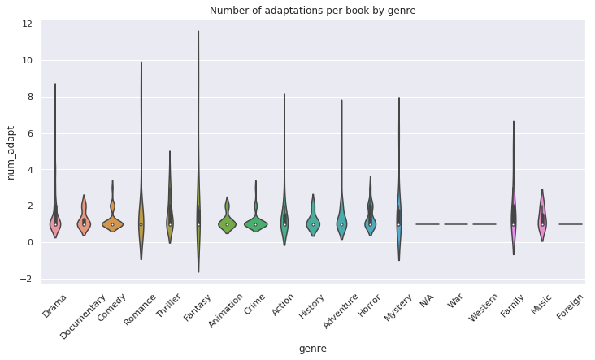

```python
import seaborn as sns
import numpy as np
import matplotlib.pylab as plt

sns.set(rc={'figure.figsize':(12,6)})
g = sns.violinplot(data=adapt_per_book_df, x='genre', y='num_adapt')
plt.xticks(rotation=45)
g.set_title('Number of adaptations per book by genre')
```

## Rankings

Now it is time to integrate ranking data. To start, we can generate a scatter plot between book ranking and the average ranking of the corresponding adaptation(s). We will perform a linear regression as well.

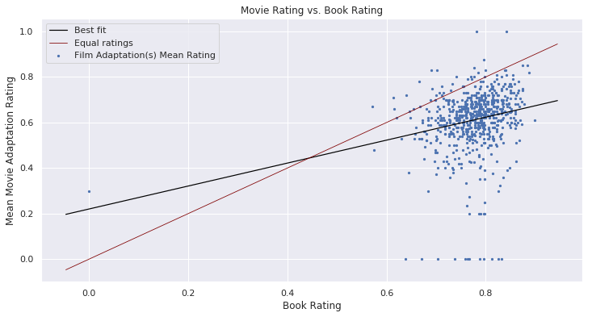

```python
import matplotlib.pyplot as plt
from scipy import stats

# Scatter film adaptation ranking (out of 10) versus book rating (out of 5)
plt.scatter(x=adapt_per_book_df.book_rating,y=adapt_per_book_df.avg_film_rating,s=5, label='Film Adaptation(s) Mean Rating')
# plt.xlim([2.5,5.0])

# Plot a linear regression line
slope, intercept, _, _, _ = stats.linregress(adapt_per_book_df.book_rating, adapt_per_book_df.avg_film_rating)
left, right = plt.xlim()
x = np.linspace(left, right,num=50)
plt.plot(x, intercept + slope*x, color='black', linewidth='1.2', label='Best fit')

# Plot an "equal rating" line of books that receive the equivalent movie score
plt.plot(x, x, color='maroon', linewidth='0.8', label='Equal ratings')

plt.xlabel('Book Rating')
plt.ylabel('Mean Movie Adaptation Rating')
plt.title('Movie Rating vs. Book Rating')
plt.legend()
plt.show()
```

There is a noticeable main cluster with a center roughly at (0.8, 0.6). The black line is a linear regression through our data. The red line is a line on which would lie movies that receive the same score as their books. Since the main cluster is positioned below this line, it suggests that viewers don't usually judge movies to be as good as the books they were based on. Why is this? One on hand, it may have to do with the particular production company, director, and budget that happen to take on a book. On the other, it likely has an explanation rooted in sociological and cultural phenomena. While these reasons are not necessarily beyond the scope of data science, they are outside the ability of the particular datasets we are using (Goodreads and MovieLens) to explain.

You can see at the bottom that there are quite a few books with decent ratings that received 0-point movie ratings.

## Film vs Book rankings by genre

Next, we can see if there is any pattern in regard to genre: do books of particular genres tend to be made into better movies? Since there are 19 unique genres, I will only consider the most common.

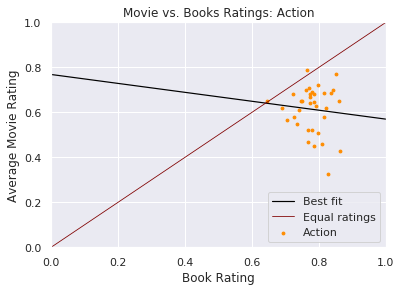

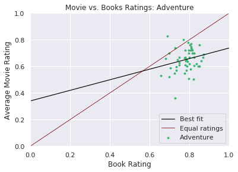

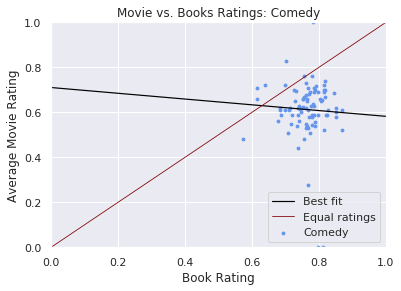

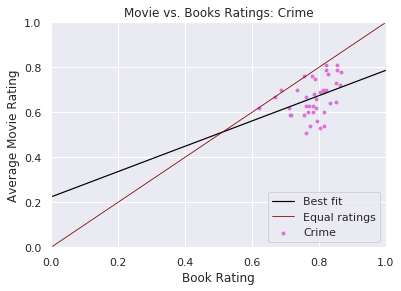

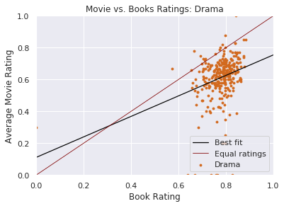

```python
# Determine the five most common genres. We could consider all 19 but
# the graph would be difficult to read.
cc = Counter(adapt_per_book_df.genre.to_list())
most_common_genres_counter = cc.most_common(5)
most_common_genres = []
for genre_tuple in most_common_genres_counter:
    (genre,_) = genre_tuple
    most_common_genres.append(genre)

colors = ['darkorange','mediumseagreen','cornflowerblue','orchid','chocolate']
counter = 0

# Go through adaptations by genre and plot each one in an individual subplot.
for (genre, df) in adapt_per_book_df.groupby(by='genre'):
    if genre not in most_common_genres:
        continue

    plt.figure(counter + 1, figsize=(6,24))
    axis = plt.subplot(5, 1, counter + 1)
    plt.xlim([0,1])
    plt.ylim([0,1])

    plt.scatter(x=df.book_rating,y=df.avg_film_rating,s=8,label=genre,c=colors[counter])
    slope, intercept, _, _, _ = stats.linregress(df.book_rating, df.avg_film_rating)
    left, right = plt.xlim()
    x = np.linspace(left, right,num=50)
    plt.plot(x, intercept + slope*x, color='black', linewidth='1.2', label='Best fit')
    plt.plot(x, x, color='maroon', linewidth='0.8', label='Equal ratings')

    plt.xlabel('Book Rating')
    plt.ylabel('Average Movie Rating')
    plt.title(f'Movie vs. Books Ratings: {genre}')
    plt.legend(loc='lower right')
    counter += 1

plt.show()
```

From these individual scatter plots, we can see that there's no particular genre among the five examined that tends to get turned into movies that are as good or better: no genre shows has many points around or above the maroon 'equal ratings' line. In fact, there is a slight negative linear trend for books that are turned into action and comedy movies, suggesting that books of these genres are adapted poorly in comparison to drama, crime, and adventure.

Once again, we see that most movie adaptations have a lower relative score in comparison to their original book, but for indidvidual genres. Some possible reasons are that we tend to be disappointed by movie adaptations because they are simply poorly produced, or that we tend to be harsher when rating movies versus books.

## Hypothesis Testing

To formalize the experiment above, I'll perform a linear regression that attempts to find a correlation between movie rating, book rating, and genre.

Null hypothesis: Genre does not have a significant impact on movie rating.  
Alternative hypothesis: Genre, in addition to book rating, has a significant impact on movie rating.

```python
import statsmodels.formula.api as smf

# Add book genre as a new column for each film adaptation.
# This is just the most frequent label applied to its adaptations.
def get_book_genre(title):
    return adapt_per_book_df[adapt_per_book_df['title'] == title].iloc[0].genre

adaptations['book_genre'] = adaptations.title.apply(get_book_genre)

# We are seeking to see if this relationship exists in a significant way.
mod = smf.ols(formula='vote_average ~ average_rating + book_genre', data=adaptations)
res = mod.fit()
# res.pvalues
res.summary()
```

OLS Regression Results

| Dep. Variable: | vote_average | R-squared: | 0.072 |
| --- | --- | --- | --- |
| Model: | OLS | Adj. R-squared: | 0.054 |
| Method: | Least Squares | F-statistic: | 3.931 |
| Date: | Sat, 13 Jul 2019 | Prob (F-statistic): | 3.43e-08 |
| Time: | 19:16:54 | Log-Likelihood: | 474.89 |
| No. Observations: | 983 | AIC: | -909.8 |
| Df Residuals: | 963 | BIC: | -812.0 |
| Df Model: | 19 |  |  |
| Covariance Type: | nonrobust |  |  |

|  | coef | std err | t | P>\|t\| | [0.025 | 0.975] |
| --- | --- | --- | --- | --- | --- | --- |
| Intercept | 0.2482 | 0.067 | 3.700 | 0.000 | 0.117 | 0.380 |
| book_genre[T.Adventure] | 0.0468 | 0.027 | 1.712 | 0.087 | -0.007 | 0.101 |
| book_genre[T.Animation] | 0.0147 | 0.047 | 0.313 | 0.755 | -0.077 | 0.107 |
| book_genre[T.Comedy] | 0.0287 | 0.025 | 1.130 | 0.259 | -0.021 | 0.079 |
| book_genre[T.Crime] | 0.0691 | 0.031 | 2.262 | 0.024 | 0.009 | 0.129 |
| book_genre[T.Documentary] | 0.0687 | 0.052 | 1.319 | 0.187 | -0.033 | 0.171 |
| book_genre[T.Drama] | 0.0108 | 0.022 | 0.490 | 0.624 | -0.032 | 0.054 |
| book_genre[T.Family] | 0.0008 | 0.041 | 0.020 | 0.984 | -0.080 | 0.082 |
| book_genre[T.Fantasy] | -0.0180 | 0.035 | -0.508 | 0.612 | -0.087 | 0.051 |
| book_genre[T.Foreign] | -0.0286 | 0.109 | -0.262 | 0.793 | -0.242 | 0.185 |
| book_genre[T.History] | 0.0452 | 0.065 | 0.694 | 0.488 | -0.082 | 0.173 |
| book_genre[T.Horror] | -0.0019 | 0.031 | -0.062 | 0.951 | -0.063 | 0.059 |
| book_genre[T.Music] | 0.0507 | 0.078 | 0.647 | 0.518 | -0.103 | 0.204 |
| book_genre[T.Mystery] | 0.0319 | 0.042 | 0.758 | 0.448 | -0.051 | 0.115 |
| book_genre[T.N/A] | -0.2024 | 0.048 | -4.190 | 0.000 | -0.297 | -0.108 |
| book_genre[T.Romance] | 0.0152 | 0.037 | 0.414 | 0.679 | -0.057 | 0.087 |
| book_genre[T.Thriller] | 0.0099 | 0.034 | 0.295 | 0.768 | -0.056 | 0.076 |
| book_genre[T.War] | -0.0230 | 0.071 | -0.326 | 0.744 | -0.162 | 0.116 |
| book_genre[T.Western] | -0.1128 | 0.090 | -1.258 | 0.209 | -0.289 | 0.063 |
| average_rating | 0.4420 | 0.081 | 5.430 | 0.000 | 0.282 | 0.602 |

| Omnibus: | 436.369 | Durbin-Watson: | 1.820 |
| --- | --- | --- | --- |
| Prob(Omnibus): | 0.000 | Jarque-Bera (JB): | 2286.783 |
| Skew: | -2.016 | Prob(JB): | 0.00 |
| Kurtosis: | 9.291 | Cond. No. | 33.8 |

Warnings:  
[1] Standard Errors assume that the covariance matrix of the errors is correctly specified.

## Especially high-ranking books

So far, we have been looking at all book-movie adaptations. Now, I am going to see if high ranking books get turned into high-ranking movies. I will first examine the spread of book ratings to determine the cut-off for what constitutes "high ranking."

```python
adapt_per_book_df.describe()
```

|  | avg_film_rating | avg_film_revenue | book_rating | num_adapt |
| --- | --- | --- | --- | --- |
| count | 683.000000 | 6.830000e+02 | 683.000000 | 683.000000 |
| mean | 0.611930 | 3.094633e+07 | 0.777417 | 1.439239 |
| std | 0.133948 | 9.037302e+07 | 0.058854 | 1.043222 |
| min | 0.000000 | 0.000000e+00 | 0.000000 | 1.000000 |
| 25% | 0.570000 | 0.000000e+00 | 0.750000 | 1.000000 |
| 50% | 0.630000 | 0.000000e+00 | 0.786000 | 1.000000 |
| 75% | 0.690000 | 1.937238e+07 | 0.814000 | 1.000000 |
| max | 1.000000 | 9.201000e+08 | 0.898000 | 9.000000 |

```python
print(np.percentile(adapt_per_book_df.book_rating,q=[95.0]))
print(np.percentile(adapt_per_book_df.avg_film_rating,q=[95.0]))
print(np.percentile(adapt_per_book_df.avg_film_rating,q=[90.0]))
```

```
[0.852]
[0.77]
[0.73]
```

You can see above that the 95th percentile normalized book rating is 0.852 (or 4.26 out of 5). That means that the most highly rated 5% of books have a score of 0.852. The 95th percentile for movie rating is 7.7/10, while the 90th percentile movie rating is 7.3/10.

Now we are going to construct a new dataFrame of the top 5% of books.

```python
# Take books whose score is 0.852 (4.26/5.00) or more
top_books = adapt_per_book_df[adapt_per_book_df.book_rating >= 0.852]
top_books.head(6)
```

|  | avg_film_rating | avg_film_revenue | book_rating | genre | num_adapt | primary_author | title |
| --- | --- | --- | --- | --- | --- | --- | --- |
| 21 | 0.60000 | 0.000000e+00 | 0.852 | Comedy | 1 | Emil M. Cioran | A Short History of Decay |
| 28 | 0.73000 | 0.000000e+00 | 0.852 | Drama | 1 | Betty Smith | A Tree Grows in Brooklyn |
| 64 | 0.59125 | 2.111671e+08 | 0.872 | Romance | 8 | Max Eilenberg | Beauty and the Beast |
| 89 | 0.60000 | 0.000000e+00 | 0.864 | Drama | 1 | Andre Dubus | Broken Vessels |
| 127 | 0.75000 | 5.000000e+00 | 0.874 | Drama | 1 | John Steinbeck | East of Eden |
| 139 | 0.52000 | 0.000000e+00 | 0.868 | Comedy | 1 | Shel Silverstein | Falling Up |

The result is a 41-row dataFrame of the top 5% most highly rated books that were turned into adaptations. I chose the 95th percentile because I think it gives us a resulting number of observations that is small enough to look at closely, but still large enough for variety. First, I want to see how many adaptations were made of these 41 books.

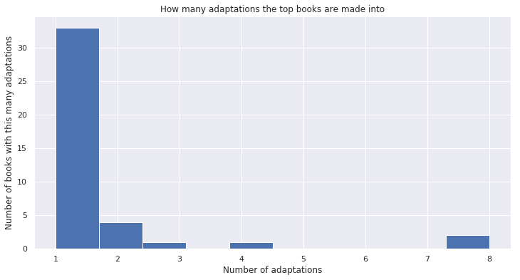

```python
plt.hist(top_books.num_adapt)
plt.xlabel('Number of adaptations')
plt.ylabel('Number of books with this many adaptations')
plt.title('How many adaptations the top books are made into')
plt.show()
```

Unsurprisingly, most have been made into just one adaptation. But out of literary curiosity, I want to see which ones have been made into 3, 4, and 8 adaptations.

```python
top_books[top_books.num_adapt >= 3]
```

|  | avg_film_rating | avg_film_revenue | book_rating | genre | num_adapt | primary_author | title |
| --- | --- | --- | --- | --- | --- | --- | --- |
| 64 | 0.591250 | 2.111671e+08 | 0.872 | Romance | 8 | Max Eilenberg | Beauty and the Beast |
| 224 | 0.597500 | 5.698826e+07 | 0.858 | Drama | 8 | Victor Hugo | Les Misérables |
| 382 | 0.600000 | 0.000000e+00 | 0.852 | Thriller | 4 | Stephen King | The Body |
| 584 | 0.706667 | 0.000000e+00 | 0.860 | Drama | 3 | Martha Hailey DuBose | The Secret Garden |

*Beauty and the Beast* is a 18th-century fairytale, while *Les Misérables* is Victor Hugo's novel that was published in 1862. Both of these have the greatest number of adaptations, and it makes sense because they are classics and have been around for a while.

Now we can look at the relationship between book and movie rating among these top 41.

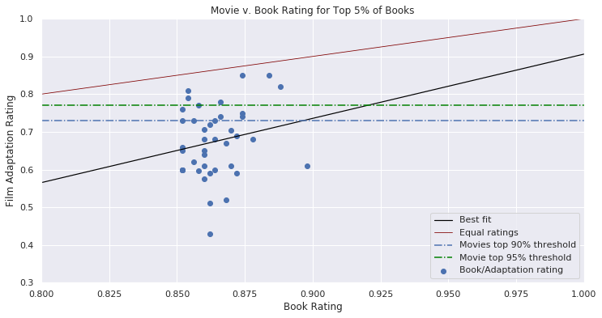

```python
# Plot movie vs. book rating
plt.scatter(x=top_books.book_rating, y=top_books.avg_film_rating, label='Book/Adaptation rating')
plt.xlim([0.8,1])
plt.ylim([0.3,1])

# Plot linear regression
slope, intercept, _, _, _ = stats.linregress(top_books.book_rating, top_books.avg_film_rating)
left, right = plt.xlim()
x = np.linspace(left, right,num=50)
plt.plot(x, intercept + slope*x, color='black', linewidth='1.2', label='Best fit')

# Plot equal ratings line, for reference
plt.plot(x, x, color='maroon', linewidth='0.8', label='Equal ratings')

# Plot 90th percentile for movie ratings, for reference
plt.axhline(0.73, linestyle='-.', label='Movies top 90% threshold')
plt.axhline(0.77, linestyle='-.', label='Movie top 95% threshold', c='green')

plt.legend(loc='lower right')
plt.xlabel('Book Rating')
plt.ylabel('Film Adaptation Rating')
plt.title('Movie v. Book Rating for Top 5% of Books')
plt.show()
```

Top books tend to get turned into movies that are rated between 4/10 and 9/10. I plotted the 90th (7.3/10.0) and 95th (7.7/10.0) percentiles of movie ratings (among movies that were adapted from books). Very few top 5% books get top 5% movie scores. This enforces my conjecture from earlier that we tend to be harsher when rating movies. If we rated them with equal judgment, then the dots would be mostly above the green line.

## Ratings over time

I want to consider books that have been made into multiple adaptations and see if there is a correlation between time and rating. I.e., do adaptations of a particular book get better over time? I will look at books that have at least four adaptations. There are 34 such books. I will perform this analysis on individual books.

```python
date_regex = re.compile("^(\d{4})-\d{2}-\d{2}$")

def get_year_from_date(date):
    match = date_regex.match(str(date))

    if match:
        return int(match.group(1))
    else:
        return 0

adaptations['year'] = adaptations['release_date'].apply(get_year_from_date)

# new dataFrame of books that have 4 or more adaptations made of them
multiple_adapt = adapt_per_book_df[adapt_per_book_df.num_adapt >= 4]
multiple_adapt.head(10)
```

|  | avg_film_rating | avg_film_revenue | book_rating | genre | num_adapt | primary_author | title |
| --- | --- | --- | --- | --- | --- | --- | --- |
| 2 | 0.627143 | 4.646198e+07 | 0.808 | Drama | 7 | Charles Dickens | A Christmas Carol |
| 16 | 0.577500 | 0.000000e+00 | 0.788 | Fantasy | 4 | William Shakespeare | A Midsummer Night's Dream |
| 36 | 0.648889 | 1.774990e+08 | 0.806 | Fantasy | 9 | Jane Carruth | Alice in Wonderland |
| 48 | 0.620000 | 1.779000e+07 | 0.808 | Drama | 4 | Leo Tolstoy | Anna Karenina |
| 64 | 0.591250 | 2.111671e+08 | 0.872 | Romance | 8 | Max Eilenberg | Beauty and the Beast |
| 121 | 0.372500 | 0.000000e+00 | 0.700 | Drama | 4 | Arthur Miller | Death of a Salesman |
| 123 | 0.545000 | 0.000000e+00 | 0.774 | Drama | 4 | Miguel de Cervantes Saavedra | Don Quixote |
| 148 | 0.691667 | 1.565333e+03 | 0.758 | Drama | 6 | Ivan Turgenev | First Love |
| 167 | 0.578000 | 1.115054e+07 | 0.718 | Drama | 5 | Kathy Acker | Great Expectations |
| 207 | 0.665000 | 5.785104e+06 | 0.822 | Drama | 6 | Charlotte Brontë | Jane Eyre |

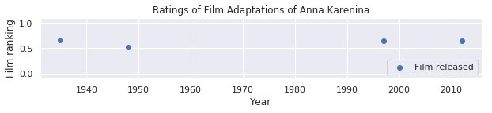

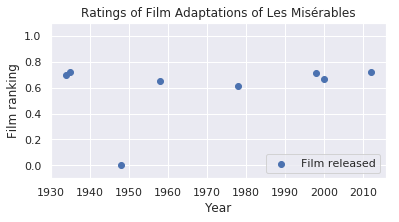

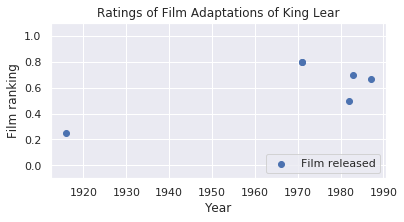

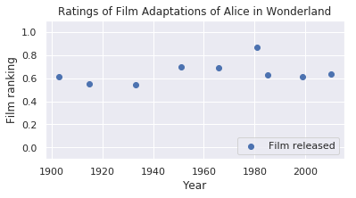

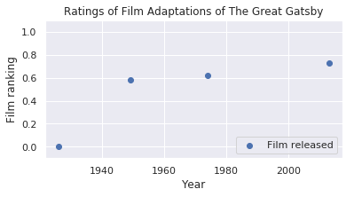

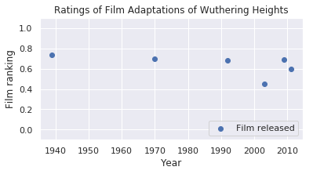

```python
# Hand pick some good novels.
selected_titles = ['Anna Karenina',
                   'Les Misérables',
                   'King Lear',
                   'Alice in Wonderland',
                   'The Great Gatsby',
                   'Wuthering Heights']
counter = 0
plt.figure(figsize=(10,10))

# Plot each book's rankings over time
for title in selected_titles:
    counter += 1
    movie_adaptations = adaptations[adaptations.title == title]

    plt.figure(counter, figsize=(6,20))
    plt.subplot(6,1,counter)

    plt.scatter(x=movie_adaptations.year, y=movie_adaptations.vote_average, label='Film released')
    plt.ylim([-0.1,1.1])
    plt.xlabel('Year')
    plt.ylabel('Film ranking')
    plt.legend(loc='lower right')
    plt.title(f'Ratings of Film Adaptations of {title}')

plt.show()
```

I picked six titles to illustrate the rating of their respective film adaptations over time. The overwhelming trend is that a book's film adaptations generally stay similar over time. For *The Great Gatsby, King Lear,* and *Les Misérables*, there is an outlier adaptation with a comparably low rating. But for the most part, there is no notable correlation between time and rating. One might venture to say that the classics remain good as they have been and always will be.

## Predicting the destiny of a book with random forest learning

In this last endeavor, I would like to see if there's an effective way of predicting if a book will get made into a movie from the attributes that were available in the Goodreads dataset. First, I have to tag our original 'books' dataFrame with a binary classification, 'adapted,' that corresponds to if they were made into one or more adaptations (True) or not (False. Then, I'm going to get rid of the features that don't make sense for classification such as ID, ISBN, title and author.

```python
# Un-normalize book rating back to a 5-point scale since we are now only
# dealing with books.
books['average_rating'] = books['average_rating'].apply(lambda x : x * 5)

def was_adapted(title):
    num_adapts = adaptations[adaptations['title'] == title].shape[0]
    if num_adapts > 0:
        return True
    else:
        return False

# The column'adapted' will serve as the predictions of our test data.
books['adapted'] = books['title'].apply(was_adapted)
book_features = books.loc[:,['average_rating','# num_pages',
                             'ratings_count','text_reviews_count','adapted']]
```

In total, 'book_features' has 10,126 observations. I'll randomly select 1/5 of these to use to train the model.

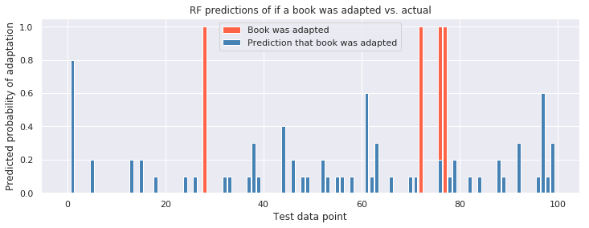

```python
from sklearn.ensemble import RandomForestClassifier
from sklearn.model_selection import train_test_split

# Split training and test data
train, test = train_test_split(book_features, train_size=0.2)
train_features = train.drop(columns=['adapted'])
train_target = train['adapted']
test_features = test.drop(columns=['adapted'])
test_target = test['adapted']

# Generate random forest on training data
clf = RandomForestClassifier(n_estimators=10)
clf = clf.fit(train_features, train_target)

# Predict on test data
predicted_proba = clf.predict_proba(test_features)
proba_false = predicted_proba[:,0]
proba_true = predicted_proba[:,1]

proba_false_cropped = proba_false[:100]
proba_true_cropped = proba_true[:100]
target_cropped = test_target[:100]

ind = np.arange(proba_false_cropped.shape[0])

plt.figure(figsize=(12,4))
p3 = plt.bar(ind, target_cropped, color='tomato', label='Book was adapted')
p2 = plt.bar(ind, proba_true_cropped, color='steelblue', label='Prediction that book was adapted')
plt.legend()
plt.xlabel('Test data point')
plt.ylabel('Predicted probability of adaptation')
plt.title('RF predictions of if a book was adapted vs. actual')
plt.show()
```

The plot above visualizes a small sample of the test data and predictions (100 out of 8101). The x-axis is not meaningful; it simply measures the location of a data point in the test dataset array. The blue bars at the bottom represent the predicted probability of True. For example, if, at x=20, the blue bar measures 0.4, that means that the model has predicted there to be a 40% chance that that book is made into an adaptation.

The red bar represents if the given book was actually made into an adaptation. If there are data points for which the red bar appears, but the blue bar is not visible (probability true = 0), then the model predicted that the book would not be adapted, whereas in reality it was. If the blue and red bars are both visible for a given data point, and if the blue bar is nearly as high as the red bar, then the model had a more accurate prediction.

To interpret the model's performance numerically, we can use the score function.

```python
clf.score(test_features, test_target)
```

```
0.9267991605974572
```

When we test on all points in the test dataset, the mean accuracy is 0.92. As a reminder, the decision trees in our random forest are based on these four features of a book: average rating, number of pages, number of ratings, and number of text reviews. While it looks from the score as if these four features are able to predict whether a book will be made into a movie or not, I take it with a grain of salt: the results of our classifier may be skewed because the overwhelming majority of books are not made into adaptations (i.e., we did not have a roughly equal number of data points for adapted=False and adapted=true). From the graph of the sample of tested data, you can see there are a great deal of false negatives where the model was not able to predict that the book was adapted even though it was.

When the random forest classifier is created, it generates 10 decision trees. We can select one of them to view. Unfortunately, I could not produce a visualization of a tree because I was having trouble configuring the necessary packages in the Jupyter environment. But I provide below the code necessary to produce one of the ten trees in the forest. All ten can be printed as well by iterating over 'clf.estimators_'.

```python
## Uncomment to produce an image of a decision tree

# from sklearn import tree
# import pydotplus
# from IPython.display import Image

# selected_tree = clf.estimators_[5]

# dot_data = tree.export_graphviz(selected_tree, out_file=None, feature_names=test_features.columns,class_names=test_target.columns,\
#                                filled=True, rounded=True)
# graph = pydotplus.graph_from_dot_data(dot_data)
# Image(graph.create_png())
```

## Conclusion: Things to take into account

In this tutorial, we've explored how book relate to movie adaptations. The biggest challenge in connecting these two domains is entity resolution: with the datasets alone, or even with outside help, it's difficult to automate a process that accurately links movies to books. My simple approach assumes that a movie is adapted from a book when it has the same title of two or more words.

This works a lot of the time, but it also doesn't work a lot of the time. Think of "First Love" as a generic rom com title. It's the English-translated title of six movies in our dataset, but only one of them is an adaptation of Ivan Turgenev's novella of the same name. Most often, the biggest problem is that movie adaptations are given a slightly different title that retains some keywords of the original book title but isn't exactly identical character for character. One idea to improve upon book-movie record linkage is to take an NLP approach to measuring similarity that places less weight on or even understand substitutions of generic words like "the" or "on." This tutorial performs a basic matching that sacrifices accuracy for simplicity, but which does enough to permit us a general idea of what the information we're after.

We looked primarily at how book and movie rankings compare. By performing linear regression, we found that there was a slight positive correlation between book and movie ranking, but that when normalized, movies tend to be rated more poorly, in general and for the specific genres we examined. I believe this difference has less to do with objective "goodness" of either form but rather about the difference in attitude toward books and movies in our culture as well as the gap in translation that results from it.

Once again, my approach is a simplified one that assumes that user's ratings correlate directly with an absolute "goodness" of a book plot or appeal. It's nice to assume that book rankings correlate directly with movie rankings, but in reality, they can almost be considered different entities in their authorship, form, and presentation. The "goodness" of a movie depends on much more than the book it is based on. Some of these dependencies are the director, the production company, the budget, and pure chance of if and which production company takes in interest in it, and such. One approach could be to to assign a "capacity" or "potential" score to each production company based on the average ratings of movies they produce: then, the rating of a movie in production could be predicted based on this score. We might find there to be a clear relationship, or not, since the same production companies might be capable of producing good or bad movies.

Lastly, our interpretation of book/movie excellence relies solely on user ratings. As such, the ratings we've been using are subject to subjective evaluation, personal preference, error in recording, and all the things that come up when our data source is founded in opinion. It's important to understand that while ratings give us a general idea of a movie's quality, popularity, and box office performance, they don't necessarily lend to and might even contradict our personal beliefs about it.

## Further Reading

**Technical**  
[MovieLens background](https://grouplens.org/blog/movielens-datasets-context-and-history/): for those who want to read more about why MovieLens was created and how it is designed.  
[Random Forest](https://towardsdatascience.com/understanding-random-forest-58381e0602d2): for those who want to read more about decision tree and random forest learning, which I used for making predictions about if a book will be made into a movie based on a book's attributes such as number of ratings given, average rating, number of pages.

**More about book-to-movie translation:**  
[Washington Post](https://www.washingtonpost.com/news/wonk/wp/2016/01/05/the-book-really-is-better-than-the-movie/?noredirect=on&utm_term=.c0dc2bda8544): a similar data science approach that claims that books are better than movies  
[Wired](https://www.wired.com/2010/08/great-geek-debates-books-vs-movies/): an article that hypothesizes the specific elements (such as visual effects, time investment, quotability) which account for this difference in translation  
[Barnes and Nobles](https://www.barnesandnoble.com/blog/6-reasons-the-book-is-almost-always-better-than-the-movie/): same intent as Wired article, but with a more casual, common sense qualitative approach

[figure not shown]

*Thanks for reading*